# Investigating the Relationship between Mental Health and Income Inequality

Team 6

2022-03-26

# Technical Analysis

## Instructions

Technical analysis (R code), 25% (First attempt due: Mar 28 Monday 12:30pm)

Just before your team presentation, provide an R-markdown, or R script file, which shows the R-code and brief explanations as well as the rationale of the Exploratory Data Analysis of your project. (Also submit your data file, or give the online source url.) This submission, together with your final document (in part VI), will determine your team’s grade. This document shows a technical person the math/stat/codes that you used in your analysis.

The document should include:

- Summary of the dataset
- Descriptive Statistics
- Graphical representations of the data
- [When applicable] Measures of Variance / sd
- [When applicable] Normality tests
- [When applicable] Initial correlation / Chi Square tests / ANOVA analysis / Z-test or Z-interval / T-test or T-interval etc.

## Summary

**Assigned to:** Mark

The variables in the dataset are:

- `region`: name of the US Census Bureau region (name)
- `division`: name of the US Census Bureau division (contained with a census region)
- `state`: state abbreviation
- `statecode`: FIPS state code
- `countycode`: FIPS county code
- `fipscode`: 5-digit FIPS Code (county-level); combines `statecode` and `countycode`
- `county`: county name
- `year`: report release year from [County Health Rankings](https://www.countyhealthrankings.org/); range of 2016-2021
- `county_ranked`: Indicates whether or not the county was ranked; 0=unranked, 1=ranked, or NA for aggregated national or state-level data
- `mental_health_days`: Average number of mentally unhealthy days reported in past 30 days (age-adjusted)
- `mental_distress_rate`: Percentage of adults reporting 14 or more days of poor mental health per month
- `inequality`: Ratio of household income at the 80th percentile to income at the 20th percentile (Income inequality)
- `median_inc`: The income where half of households in a county earn more and half of households earn less
- `hs_grad`: Percentage of adults ages 25 and over with a high school diploma or equivalent
- `college`: Percentage of adults ages 25-44 with some post-secondary education
- `unempl`: Percentage of population ages 16 and older unemployed but seeking work
- `child_poverty`: Percentage of people under age 18 in poverty
- `single_parent`: Percentage of children that live in a household headed by single parent
- `severe_housing`: Percentage of households with severe housing problems
- `food_index`: Index of factors that contribute to a healthy food environment, from 0 (worst) to 10 (best)
- `mh_providers`: rate of providers to 100,000 population
- `pop_provider_ratio`: ratio of population to mental health providers (i.e., population served per provider)
- `pop`: census population estimate
- `pct_below18`: percent of population younger than 18
- `pct_black`: percent of population that are African-American or non-Hispanic Black
- `pct_native_am`: percent of population that are Native American or Alaska Natives
- `pct_asian`: percent of population that are Asian
- `pct_pacific`: percent of population that are Native Hawaiian or Other Pacific Islander
- `pct_hispanic`: percent of population that are Hispanic
- `pct_white`: percent of population that are non-Hispanic white or Caucasian
- `pct_female`: percent of population that are female
- `pct_rural`: percent of population that live in rural areas

For more information, see [the measures online](https://www.countyhealthrankings.org/explore-health-rankings/measures-data-sources/2021-measures).

```r
# import csv as dataframe
dframe <- data.frame(read.csv("data/processed/analytic_data_2016_2021_with_regions.csv"))

# convert variables to factor
dframe$region <- factor(dframe$region)
dframe$division <- factor(dframe$division)
dframe$statecode <- factor(dframe$statecode)
dframe$countycode <- factor(dframe$countycode)
dframe$fipscode <- factor(dframe$fipscode)
dframe$county_ranked <- factor(dframe$county_ranked)

# check structure of data
str(dframe)
```

```r
# look at county_ranked var; not all counties are ranked; also some aggregated data per state and country exist in the observations
# =1 means they are ranked, =0 means unranked, and =NA is for state/national data
# print(summary(dframe$county_ranked))

# subset of dataframe including only ranked counties
ranked <- dframe %>% subset(county_ranked==1)

# subset of dataframe including only ranked counties
unranked <- dframe %>% subset(county_ranked==0)

# subset of dataframe including only aggregated data
aggregated <- dframe %>% subset(is.na(county_ranked))

# subset ranked data by region
ranked_MW <- ranked %>% subset(region=="Midwest")
ranked_NE <- ranked %>% subset(region=="Northeast")
ranked_SO <- ranked %>% subset(region=="South")
ranked_WE <- ranked %>% subset(region=="West")

# subset ranked data into annual datasets
ranked16 <- ranked %>% subset(year==2016)
ranked17 <- ranked %>% subset(year==2017)
ranked18 <- ranked %>% subset(year==2018)
ranked19 <- ranked %>% subset(year==2019)
ranked20 <- ranked %>% subset(year==2020)
ranked21 <- ranked %>% subset(year==2021)

# view size of annual datasets
df_annual_list <- list(ranked16, ranked17, ranked18, ranked19, ranked20, ranked21)
for (df in df_annual_list) {
  print(paste("Observations in", median(df$year), "data: ", nrow(df)))

}
```

Our data are identified at the county-year level. Our data set contains 19164 observations and 32 variables, although 319 of these observations are for aggregated data at the national or state level. In addition, 375 observations are for counties that are unranked by the [University of Wisconsin Population Health Institute](https://www.countyhealthrankings.org/explore-health-rankings/faq-page), suggesting that the data for these counties is less reliable.

In total, we have 18470 observations in the ranked data, combined across 6 annual reports (2016–2021). Each annual data set has between 3071 and 3084 observations, indicating that the number of ranked counties is consistent over time.

```r
# view head and tail of ranked data
xkabledplyhead(ranked, 2, title = "Table: First 2 Rows of Ranked Data")
```

Table: First 2 Rows of Ranked Data

[output not shown]

```r
xkabledplytail(ranked, 2, title = "Table: Last 2 Rows of Ranked Data")
```

Table: Last 2 Rows of Ranked Data

|  | region | division | state | statecode | countycode | fipscode | county | year | county_ranked | mental_health_days | mental_distress_rate | inequality | median_inc | hs_grad | college | unempl | child_poverty | single_parent | severe_housing | food_index | mh_providers | pop_provider_ratio | pop | pct_below18 | pct_black | pct_native_am | pct_asian | pct_pacific | pct_hispanic | … |
| --- | --- | --- | --- | --- | --- | --- | --- | --- | --- | --- | --- | --- | --- | --- | --- | --- | --- | --- | --- | --- | --- | --- | --- | --- | --- | --- | --- | --- | --- | --- |
| 19163 | West | Mountain | WY | 56 | 43 | 56043 | Washakie County | 2021 | 1 | 4.08 | 0.133 | 3.46 | 55122 | 0.865 | 0.603 | 0.0393 | 0.139 | 0.195 | 0.103 | 8.0 | 0.0040 | 252 | 7805 | 0.229 | 0.0049 | 0.0177 | 0.0082 | 8e-04 | 0.1420 | … |
| 19164 | West | Mountain | WY | 56 | 45 | 56045 | Weston County | 2021 | 1 | 3.99 | 0.136 | 5.23 | 59410 | NA | 0.604 | 0.0289 | 0.138 | 0.168 | 0.135 | 7.7 | 0.0019 | 533 | 6927 | 0.204 | 0.0065 | 0.0189 | 0.0169 | 3e-04 | 0.0411 | … |

```r
# groupby year
ranked_by_year <- ranked %>% group_by(year)

summ_by_year <- ranked_by_year %>%  summarize(num_counties = n_distinct(fipscode),
                              num_states = n_distinct(statecode),
                              wmean_inequality = weighted.mean(inequality, pop, na.rm=T),
                              wmean_mh_rate = weighted.mean(mental_distress_rate, pop, na.rm=T),
                              wmean_mh_days = weighted.mean(mental_health_days, pop, na.rm=T),
                              wmean_unempl = weighted.mean(unempl, pop, na.rm=T),
                              wmean_medinc = weighted.mean(median_inc, pop, na.rm=T),
                              )

xkabledplyhead(summ_by_year, 6, title = "Table: Data grouped by Year")
```

Table: Data grouped by Year

| year | num_counties | num_states | wmean_inequality | wmean_mh_rate | wmean_mh_days | wmean_unempl | wmean_medinc |
| --- | --- | --- | --- | --- | --- | --- | --- |
| 2016 | 3075 | 51 | 4.73 | 0.110 | 3.61 | 0.0626 | 56225 |
| 2017 | 3071 | 51 | 4.75 | 0.113 | 3.71 | 0.0537 | 58214 |
| 2018 | 3078 | 51 | 4.74 | 0.116 | 3.80 | 0.0495 | 60385 |
| 2019 | 3081 | 51 | 4.74 | 0.116 | 3.80 | 0.0443 | 62851 |
| 2020 | 3084 | 51 | 4.72 | 0.123 | 4.00 | 0.0396 | 65104 |
| 2021 | 3081 | 51 | 4.70 | 0.137 | 4.41 | 0.0373 | 68859 |

```r
# groupby year and state
ranked_by_year_state <- ranked %>% group_by(year, statecode)

summ_by_year_state <- ranked_by_year_state %>% summarize(num_obs = n(),
                                   state_name = first(state),
                                   region = first(region),
                                   wmean_inequality = weighted.mean(inequality,
                                                                    pop, na.rm = T),
                                   med_inequality = median(inequality, na.rm = T),
                                   wmean_mh_rate = weighted.mean(mental_distress_rate,
                                                                 pop, na.rm=T),
                                   med_mh_rate = median(mental_distress_rate, na.rm=T),
                                   wmean_mh_days = weighted.mean(mental_health_days,
                                                                 pop, na.rm=T),
                                   med_mh_days = median(mental_health_days, na.rm=T),
                                   wmean_unempl = weighted.mean(unempl,
                                                                pop, na.rm=T),
                                   med_unempl = median(unempl, na.rm=T),
                                   wmean_medinc = weighted.mean(median_inc,
                                                                pop, na.rm=T),
                                   med_medinc = median(median_inc, na.rm=T)
                                   )

xkabledplyhead(summ_by_year_state, 8, title = "Table: Data grouped by Year and State")
```

Table: Data grouped by Year and State

| year | statecode | num_obs | state_name | region | wmean_inequality | med_inequality | wmean_mh_rate | med_mh_rate | wmean_mh_days | med_mh_days | wmean_unempl | med_unempl | wmean_medinc | med_medinc |
| --- | --- | --- | --- | --- | --- | --- | --- | --- | --- | --- | --- | --- | --- | --- |
| 2016 | 1 | 67 | AL | South | 5.07 | 5.04 | 0.1420 | 0.148 | 4.62 | 4.8 | 0.0689 | 0.0729 | 44403 | 36939 |
| 2016 | 2 | 24 | AK | West | 3.99 | 4.15 | 0.0901 | 0.093 | 2.94 | 3.0 | 0.0701 | 0.0946 | 69745 | 63862 |
| 2016 | 4 | 15 | AZ | West | 4.59 | 4.49 | 0.1121 | 0.123 | 3.57 | 3.9 | 0.0699 | 0.0795 | 50100 | 44145 |
| 2016 | 5 | 75 | AR | South | 4.72 | 4.67 | 0.1296 | 0.135 | 4.17 | 4.4 | 0.0622 | 0.0682 | 42788 | 36964 |
| 2016 | 6 | 57 | CA | West | 5.00 | 4.75 | 0.1084 | 0.113 | 3.60 | 3.8 | 0.0762 | 0.0865 | 63249 | 51827 |
| 2016 | 8 | 60 | CO | West | 4.41 | 4.32 | 0.0902 | 0.093 | 3.10 | 3.1 | 0.0509 | 0.0470 | 62952 | 48604 |
| 2016 | 9 | 8 | CT | Northeast | 5.13 | 4.40 | 0.0979 | 0.097 | 3.36 | 3.4 | 0.0662 | 0.0646 | 70791 | 69613 |
| 2016 | 10 | 3 | DE | South | 4.35 | 4.14 | 0.1074 | 0.110 | 3.56 | 3.5 | 0.0574 | 0.0574 | 60177 | 54271 |

```r
# groupby region
ranked_by_region <- ranked %>% group_by(region)

summ_by_region <- ranked_by_region %>%  summarize(num_counties = n_distinct(fipscode),
                              num_states = n_distinct(statecode),
                              wmean_inequality = weighted.mean(inequality, pop, na.rm=T),
                              wmean_mh_rate = weighted.mean(mental_distress_rate, pop, na.rm=T),
                              wmean_mh_days = weighted.mean(mental_health_days, pop, na.rm=T),
                              wmean_unempl = weighted.mean(unempl, pop, na.rm=T),
                              wmean_medinc = weighted.mean(median_inc, pop, na.rm=T),
                              )

xkabledplyhead(summ_by_region, 4, title = "Table: Data grouped by Region")
```

Table: Data grouped by Region

| region | num_counties | num_states | wmean_inequality | wmean_mh_rate | wmean_mh_days | wmean_unempl | wmean_medinc |
| --- | --- | --- | --- | --- | --- | --- | --- |
| Midwest | 1037 | 12 | 4.50 | 0.117 | 3.82 | 0.0453 | 58907 |
| Northeast | 217 | 9 | 5.13 | 0.117 | 3.88 | 0.0478 | 68950 |
| South | 1414 | 17 | 4.70 | 0.125 | 4.02 | 0.0470 | 56914 |
| West | 437 | 13 | 4.69 | 0.114 | 3.76 | 0.0511 | 67705 |

```r
# groupby year and state
ranked_by_year_region <- ranked %>% group_by(year, region)

summ_by_year_region <- ranked_by_year_region %>% summarize(num_obs = n(),
                                   region_name = first(region),
                                   sum_pop_millions = sum(pop/1000000, na.rm = T),
                                   wmean_inequality = weighted.mean(inequality, pop, na.rm = T),
                                   wmean_mh_rate = weighted.mean(mental_distress_rate, pop, na.rm=T),
                                   wmean_mh_days = weighted.mean(mental_health_days, pop, na.rm=T)
                                   )

xkabledplyhead(summ_by_year_region, 8, title = "Table: Data grouped by Year and Region")
```

Table: Data grouped by Year and Region

| year | region | num_obs | region_name | sum_pop_millions | wmean_inequality | wmean_mh_rate | wmean_mh_days |
| --- | --- | --- | --- | --- | --- | --- | --- |
| 2016 | Midwest | 1026 | Midwest | 67.7 | 4.50 | 0.105 | 3.52 |
| 2016 | Northeast | 217 | Northeast | 56.2 | 5.07 | 0.109 | 3.64 |
| 2016 | South | 1410 | South | 119.8 | 4.72 | 0.115 | 3.71 |
| 2016 | West | 422 | West | 75.2 | 4.71 | 0.106 | 3.53 |
| 2017 | Midwest | 1027 | Midwest | 67.9 | 4.52 | 0.109 | 3.60 |
| 2017 | Northeast | 217 | Northeast | 56.3 | 5.11 | 0.111 | 3.70 |
| 2017 | South | 1411 | South | 121.2 | 4.72 | 0.118 | 3.82 |
| 2017 | West | 416 | West | 76.0 | 4.72 | 0.109 | 3.64 |

We also grouped the data on several dimensions using the `group_by()` and `summarise()` functions from the dplyr package. This helped us better investigate time and geographic patterns in our data.

First, we grouped the data set by report year and calculating the population-weighted means for several variables. In general, the mean income inequality has stayed relatively constant over time, while the mental health variables have risen slightly. Other economic variables, such as unemployment and median income, have moved in positive directions (unemployment has fallen, while median incomes have increased).

Next, we grouped the data by year and state and calculated population-weighted means and state-level medians. There was a lot more variation among the data at this level, which will be helpful when plotting aggregated data later.

## Descriptive Statistics

**Assigned to:** Alex

```r
summary()
xkablesummary()
```

## Graphs and Figures

**Assigned to:** Mark (with help from Shumel & Xuan)

For example, histograms, boxplots, scatterplots, line graphs (for aggregated annual data), etc. We should use the `ggplot()` function.

```r
loadPkg("ggplot2")
loadPkg("patchwork") ## for combining graphs
loadPkg("purrr")
loadPkg("tidyr")
loadPkg("gridExtra")
```

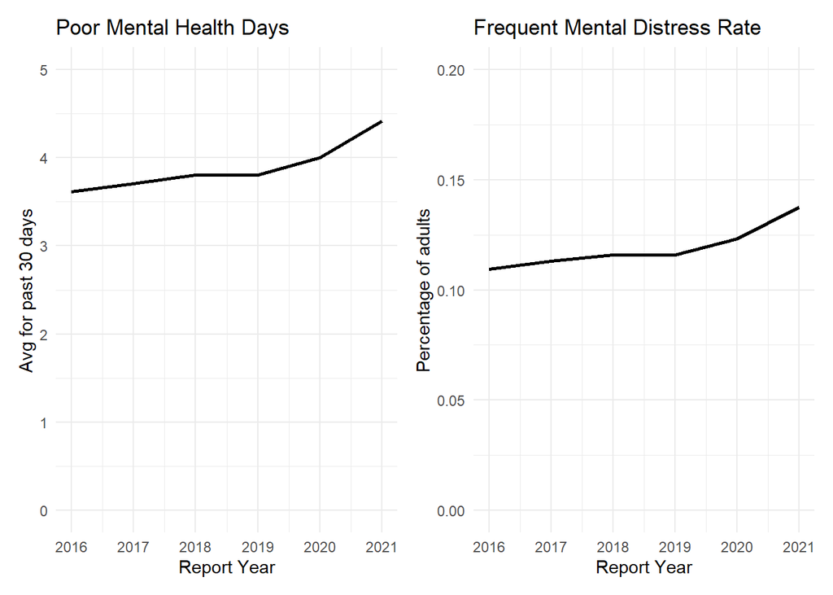

```r
# use summ_by_year

# annual trends for mental health var
p1 <- ggplot(summ_by_year, aes(x=year)) +
  geom_line(aes(y = wmean_mh_days), lwd=1) +
  expand_limits(y=c(0,5)) +
  labs(title = "Poor Mental Health Days",
       x = "Report Year", y = "Avg for past 30 days") +
  theme_minimal()

p2 <- ggplot(summ_by_year, aes(x=year)) +
  geom_line(aes(y = wmean_mh_rate), lwd=1) +
  expand_limits(y=c(0,.2)) +
  labs(title = "Frequent Mental Distress Rate",
       x = "Report Year", y = "Percentage of adults") +
  theme_minimal()

# combine plots using patchwork package
p1 + p2
```

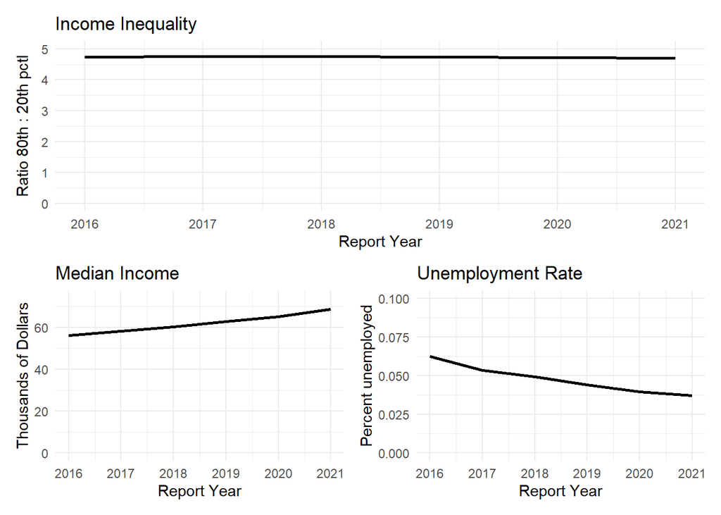

```r
# annual trends for inequality and median income
p3 <- ggplot(summ_by_year, aes(x=year)) +
  geom_line(aes(y = wmean_inequality), lwd=1) +
  expand_limits(y=c(0,5)) +
  labs(title = "Income Inequality",
       x = "Report Year", y = "Ratio 80th : 20th pctl") +
  theme_minimal()

p4 <- ggplot(summ_by_year, aes(x=year)) +
  geom_line(aes(y = wmean_medinc / 1000), lwd=1) +
  expand_limits(y=c(0,max(summ_by_year$wmean_medinc/1000)+5)) +
  labs(title = "Median Income",
       x = "Report Year", y = "Thousands of Dollars") +
  theme_minimal()

p5 <- ggplot(summ_by_year, aes(x=year)) +
  geom_line(aes(y = wmean_unempl), lwd=1) +
  expand_limits(y=c(0,.10)) +
  labs(title = "Unemployment Rate",
       x = "Report Year", y = "Percent unemployed") +
  theme_minimal()

# combine plots
p3 / (p4 + p5)
```

To visualize trends over time, we graphed several variables from the data, grouped by report year. Both measures of mental health have increased, but it’s difficult to tell whether these increases are substantial. Notably, income inequality appears largely flat, while median income and unemployment have slightly improved.

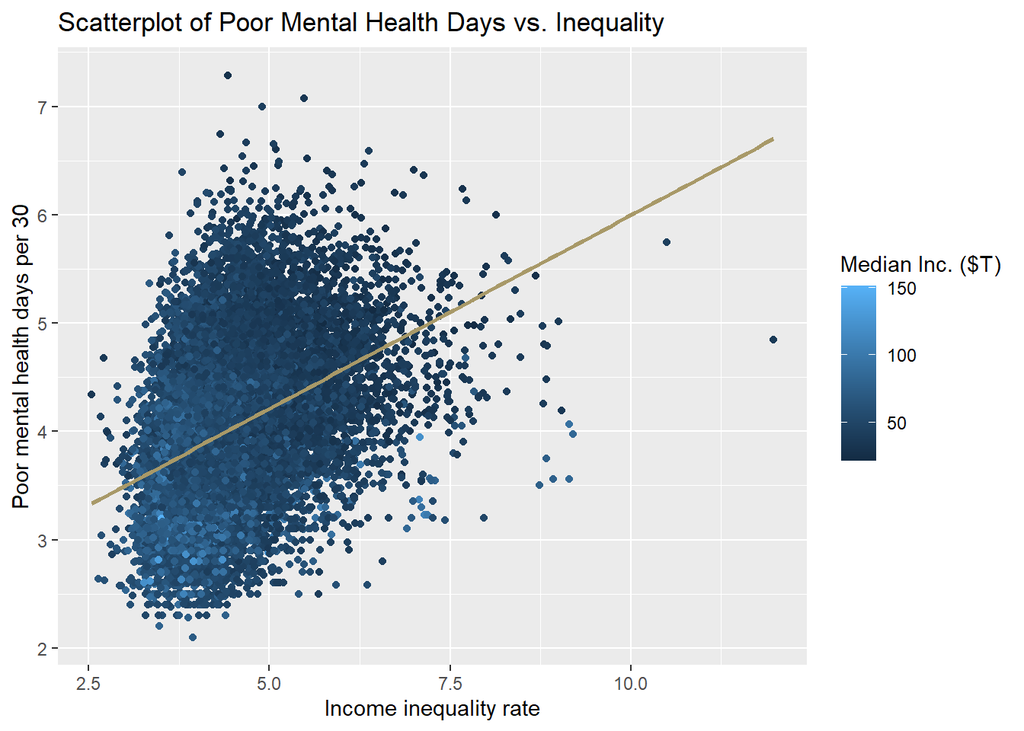

```r
# data: use ranked
# colnames(ranked)

#-- Dependent vs Explanatory --#

# color = median income
color_value <- "Median Inc. ($T)"

ggplot(ranked, aes(y=mental_health_days, x=inequality, color=median_inc/1000)) +
  geom_point() +
  geom_smooth(formula = y ~ x, method=lm, se=FALSE, color="#a89968") +  ## Add linear regression line
  labs(title = "Scatterplot of Poor Mental Health Days vs. Inequality",
       y = 'Poor mental health days per 30', x = 'Income inequality rate',
       color = color_value)
```

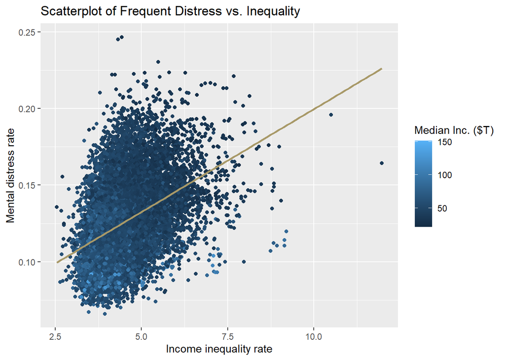

```r
ggplot(ranked, aes(y=mental_distress_rate, x=inequality, color=median_inc/1000)) +
  geom_point() +
  geom_smooth(formula = y ~ x, method=lm, se=FALSE, color="#a89968") +
  labs(title = "Scatterplot of Frequent Distress vs. Inequality",
       y = 'Mental distress rate', x = 'Income inequality rate',
       color = color_value)
```

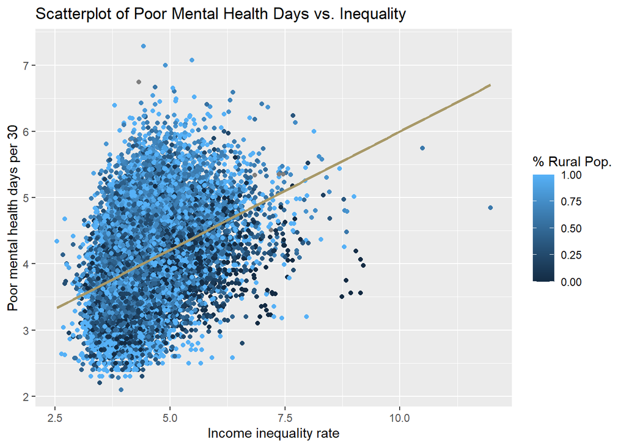

```r
# color = % rural
color_value <- "% Rural Pop."

ggplot(ranked, aes(y=mental_health_days, x=inequality, color=pct_rural)) +
  geom_point() +
  geom_smooth(formula = y ~ x, method=lm, se=FALSE, color="#a89968") +  ## Add linear regression line
  labs(title = "Scatterplot of Poor Mental Health Days vs. Inequality",
       y = 'Poor mental health days per 30', x = 'Income inequality rate',
       color = color_value)
```

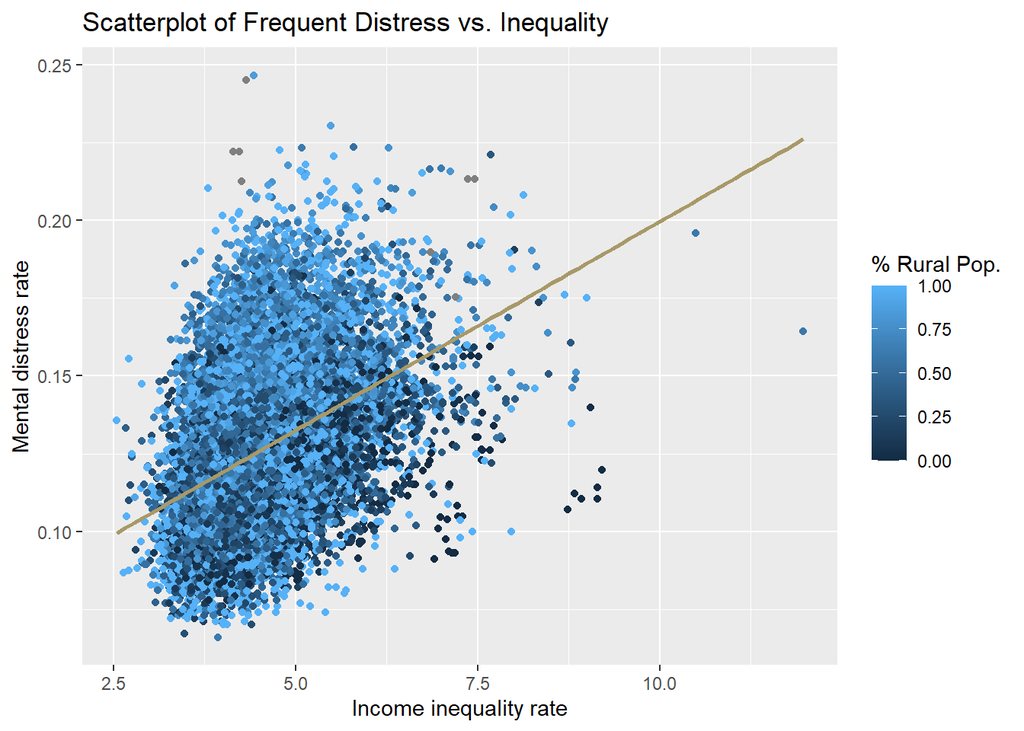

```r
ggplot(ranked, aes(y=mental_distress_rate, x=inequality, color=pct_rural)) +
  geom_point() +
  geom_smooth(formula = y ~ x, method=lm, se=FALSE, color="#a89968") +
  labs(title = "Scatterplot of Frequent Distress vs. Inequality",
       y = 'Mental distress rate', x = 'Income inequality rate',
       color = color_value)
```

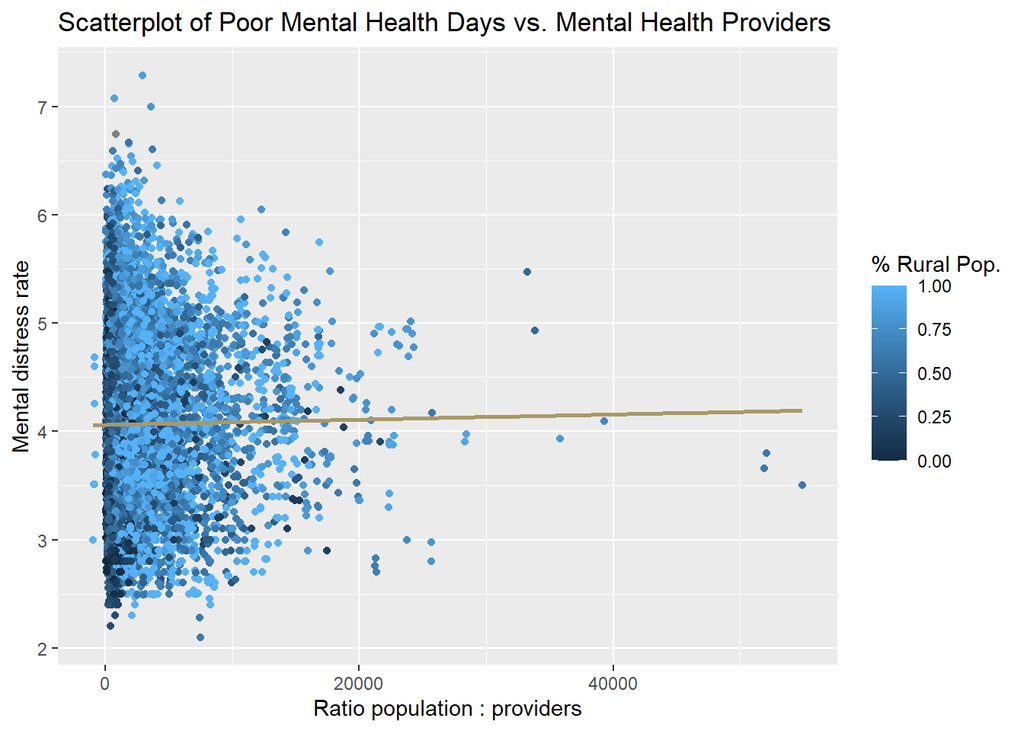

```r
#-- Dependent vs. Provision of Mental Health Care --#

# color = % rural
color_value <- "% Rural Pop."

ggplot(ranked, aes(y=mental_health_days, x=pop_provider_ratio, color=pct_rural)) +
  geom_point() +
  geom_smooth(formula = y ~ x, method=lm, se=FALSE, color="#a89968") +
  labs(title = "Scatterplot of Poor Mental Health Days vs. Mental Health Providers",
       y = 'Mental distress rate', x = 'Ratio population : providers',
       color = color_value)
```

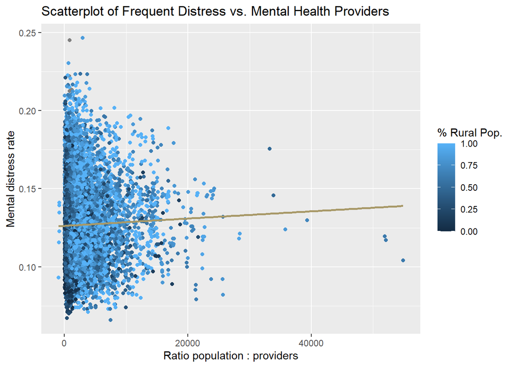

```r
ggplot(ranked, aes(y=mental_distress_rate, x=pop_provider_ratio, color=pct_rural)) +
  geom_point() +
  geom_smooth(formula = y ~ x, method=lm, se=FALSE, color="#a89968") +
  labs(title = "Scatterplot of Frequent Distress vs. Mental Health Providers",
       y = 'Mental distress rate', x = 'Ratio population : providers',
       color = color_value)
```

Next, we graphed the county-level data using scatterplots to compare the mental health measures with economic variables.

Both poor mental health days and the frequent mental distress rate are positively correlated with income inequality. When coloring the scatterplot by median income, counties with a lower median income tend toward the outer limits of the figure, which suggests that poorer counties generally have higher inequality and worse mental health. It’s harder to infer a clear relationship when coloring the points by `pct_rural`, although the many of the highly unequal counties are heavily urban.

There is not much of a correlation between the mental health outcomes and the ratio of the population to mental health providers.

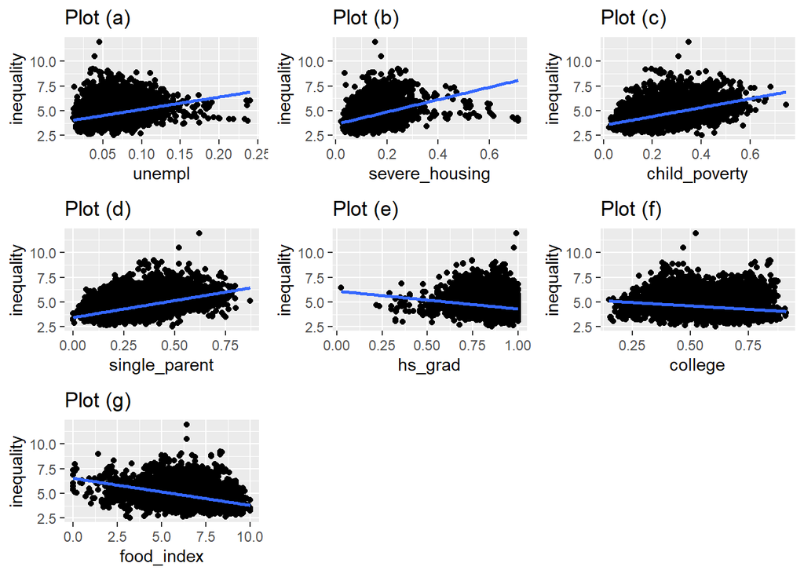

```r
# Multi-plot figures

#-- Inequality vs. other economic variables --#

# unempl, child_poverty, hs_grad, college, single_parent, severe_housing, food_index

gg1 <- ggplot(ranked, aes(y=inequality, x=unempl)) +
  geom_point() +
  geom_smooth(formula = y ~ x, method=lm, se=FALSE) +
  labs(title = "Plot (a)")

gg2 <- ggplot(ranked, aes(y=inequality, x=severe_housing)) +
  geom_point() +
  geom_smooth(formula = y ~ x, method=lm, se=FALSE) +
  labs(title = "Plot (b)")

gg3 <- ggplot(ranked, aes(y=inequality, x=child_poverty)) +
  geom_point() +
  geom_smooth(formula = y ~ x, method=lm, se=FALSE) +
  labs(title = "Plot (c)")

gg4 <- ggplot(ranked, aes(y=inequality, x=single_parent)) +
  geom_point() +
  geom_smooth(formula = y ~ x, method=lm, se=FALSE) +
  labs(title = "Plot (d)")

gg5 <- ggplot(ranked, aes(y=inequality, x=hs_grad)) +
  geom_point() +
  geom_smooth(formula = y ~ x, method=lm, se=FALSE) +
  labs(title = "Plot (e)")

gg6 <- ggplot(ranked, aes(y=inequality, x=college)) +
  geom_point() +
  geom_smooth(formula = y ~ x, method=lm, se=FALSE) +
  labs(title = "Plot (f)")

gg7 <- ggplot(ranked, aes(y=inequality, x=food_index)) +
  geom_point() +
  geom_smooth(formula = y ~ x, method=lm, se=FALSE) +
  labs(title = "Plot (g)")

plot_list <- list(gg1, gg2, gg3, gg4, gg5, gg6, gg7)

do.call("grid.arrange", c(plot_list, ncol = 3))
```

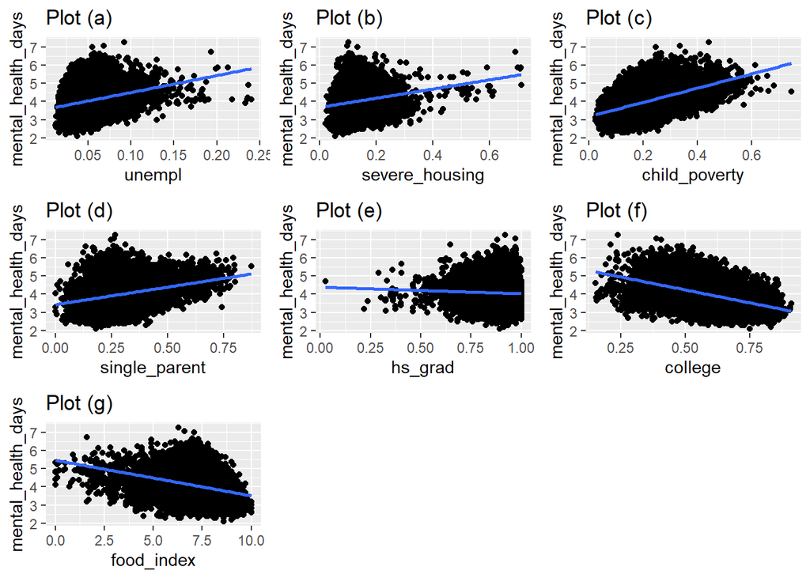

```r
#-- Dependent vs. other economic variables --#

# poor mental health days
gg1 <- ggplot(ranked, aes(y=mental_health_days, x=unempl)) +
  geom_point() +
  geom_smooth(formula = y ~ x, method=lm, se=FALSE) +
  labs(title = "Plot (a)")

gg2 <- ggplot(ranked, aes(y=mental_health_days, x=severe_housing)) +
  geom_point() +
  geom_smooth(formula = y ~ x, method=lm, se=FALSE) +
  labs(title = "Plot (b)")

gg3 <- ggplot(ranked, aes(y=mental_health_days, x=child_poverty)) +
  geom_point() +
  geom_smooth(formula = y ~ x, method=lm, se=FALSE) +
  labs(title = "Plot (c)")

gg4 <- ggplot(ranked, aes(y=mental_health_days, x=single_parent)) +
  geom_point() +
  geom_smooth(formula = y ~ x, method=lm, se=FALSE) +
  labs(title = "Plot (d)")

gg5 <- ggplot(ranked, aes(y=mental_health_days, x=hs_grad)) +
  geom_point() +
  geom_smooth(formula = y ~ x, method=lm, se=FALSE) +
  labs(title = "Plot (e)")

gg6 <- ggplot(ranked, aes(y=mental_health_days, x=college)) +
  geom_point() +
  geom_smooth(formula = y ~ x, method=lm, se=FALSE) +
  labs(title = "Plot (f)")

gg7 <- ggplot(ranked, aes(y=mental_health_days, x=food_index)) +
  geom_point() +
  geom_smooth(formula = y ~ x, method=lm, se=FALSE) +
  labs(title = "Plot (g)")

plot_list <- list(gg1, gg2, gg3, gg4, gg5, gg6, gg7)

do.call("grid.arrange", c(plot_list, ncol = 3))
```

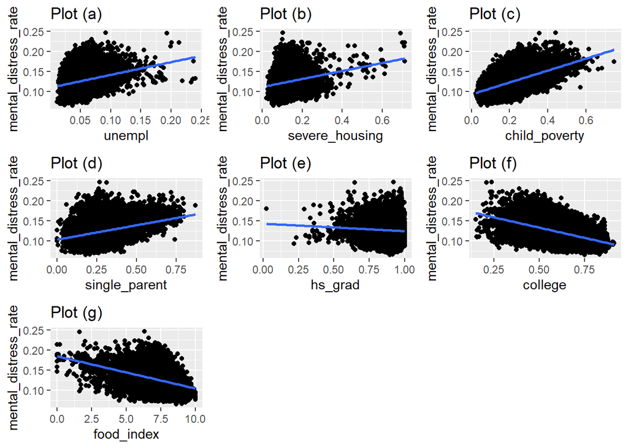

```r
# mental distress rate
gg1 <- ggplot(ranked, aes(y=mental_distress_rate, x=unempl)) +
  geom_point() +
  geom_smooth(formula = y ~ x, method=lm, se=FALSE) +
  labs(title = "Plot (a)")

gg2 <- ggplot(ranked, aes(y=mental_distress_rate, x=severe_housing)) +
  geom_point() +
  geom_smooth(formula = y ~ x, method=lm, se=FALSE) +
  labs(title = "Plot (b)")

gg3 <- ggplot(ranked, aes(y=mental_distress_rate, x=child_poverty)) +
  geom_point() +
  geom_smooth(formula = y ~ x, method=lm, se=FALSE) +
  labs(title = "Plot (c)")

gg4 <- ggplot(ranked, aes(y=mental_distress_rate, x=single_parent)) +
  geom_point() +
  geom_smooth(formula = y ~ x, method=lm, se=FALSE) +
  labs(title = "Plot (d)")

gg5 <- ggplot(ranked, aes(y=mental_distress_rate, x=hs_grad)) +
  geom_point() +
  geom_smooth(formula = y ~ x, method=lm, se=FALSE) +
  labs(title = "Plot (e)")

gg6 <- ggplot(ranked, aes(y=mental_distress_rate, x=college)) +
  geom_point() +
  geom_smooth(formula = y ~ x, method=lm, se=FALSE) +
  labs(title = "Plot (f)")

gg7 <- ggplot(ranked, aes(y=mental_distress_rate, x=food_index)) +
  geom_point() +
  geom_smooth(formula = y ~ x, method=lm, se=FALSE) +
  labs(title = "Plot (g)")

plot_list <- list(gg1, gg2, gg3, gg4, gg5, gg6, gg7)

do.call("grid.arrange", c(plot_list, ncol = 3))
```

To get a better sense of how income inequality is associated with the other economic variables, we created a figure with multiple scatterplots. In general, the variables suggest the expected relationship: for example, `inequality` is positively correlated with unemployment, severe housing issues, and child poverty but negatively associated with a better food environment and high school graduation rates. Both `mental_health_days` and `mental_distress_rate` exhibit similarly signed correlations with the economic variables.

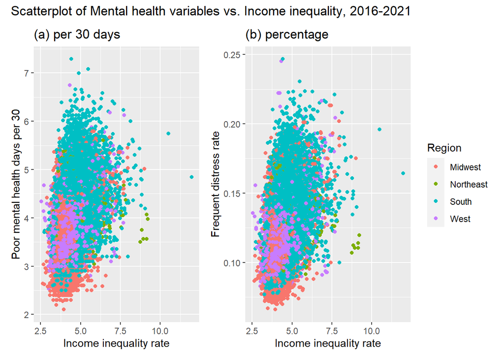

```r
# data: use ranked
# color = % rural
color_value <- "Region"

#-- All Years --#

p1 <- ggplot(ranked, aes(y=mental_health_days, x=inequality, color = factor(region))) +
  geom_point(show.legend = F) +
  labs(title = paste("(a) per 30 days"),
       y = 'Poor mental health days per 30', x = 'Income inequality rate',
       color = color_value)

p2 <- ggplot(ranked, aes(y=mental_distress_rate, x=inequality, color = factor(region))) +
  geom_point() +
  labs(title = paste("(b) percentage"),
       y = 'Frequent distress rate', x = 'Income inequality rate',
       color = color_value)

p_all <- p1 + p2 + plot_annotation(title = "Scatterplot of Mental health variables vs. Income inequality, 2016-2021")
p_all
```

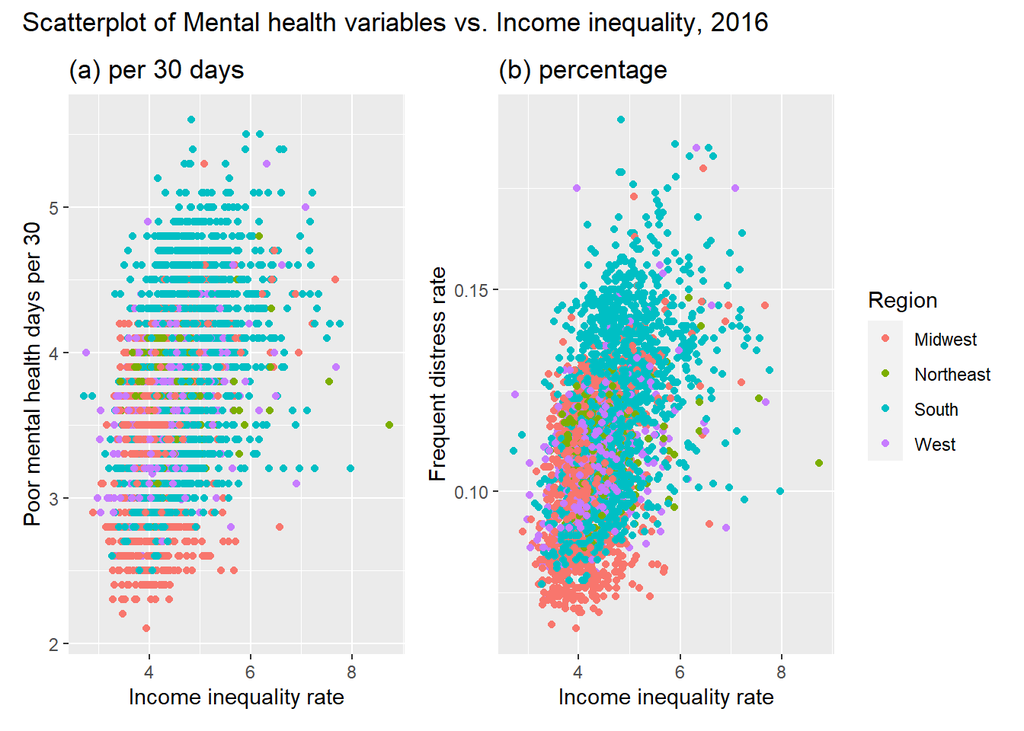

```r
#-- Is relationship sensitive to report year? --#

# 2016 vs 2021

# 2016
p1 <- ggplot(ranked16, aes(y=mental_health_days, x=inequality, color = factor(region))) +
  geom_point(show.legend = F) +
  labs(title = "(a) per 30 days",
       y = 'Poor mental health days per 30', x = 'Income inequality rate',
       color = color_value)

p2 <- ggplot(ranked16, aes(y=mental_distress_rate, x=inequality, color = factor(region))) +
  geom_point() +
  labs(title = "(b) percentage",
       y = 'Frequent distress rate', x = 'Income inequality rate',
       color = color_value)

p16 <- p1 + p2 + plot_annotation(title = "Scatterplot of Mental health variables vs. Income inequality, 2016")
p16
```

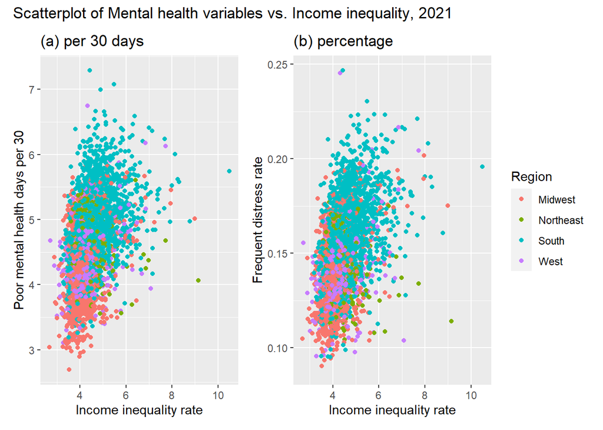

```r
# 2021
p1 <- ggplot(ranked21, aes(y=mental_health_days, x=inequality, color = factor(region))) +
  geom_point(show.legend = F) +
  labs(title = "(a) per 30 days",
       y = 'Poor mental health days per 30', x = 'Income inequality rate',
       color = color_value)

p2 <- ggplot(ranked21, aes(y=mental_distress_rate, x=inequality, color = factor(region))) +
  geom_point() +
  labs(title = "(b) percentage",
       y = 'Frequent distress rate', x = 'Income inequality rate',
       color = color_value)

p21 <- p1 + p2 + plot_annotation(title = "Scatterplot of Mental health variables vs. Income inequality, 2021")
p21
```

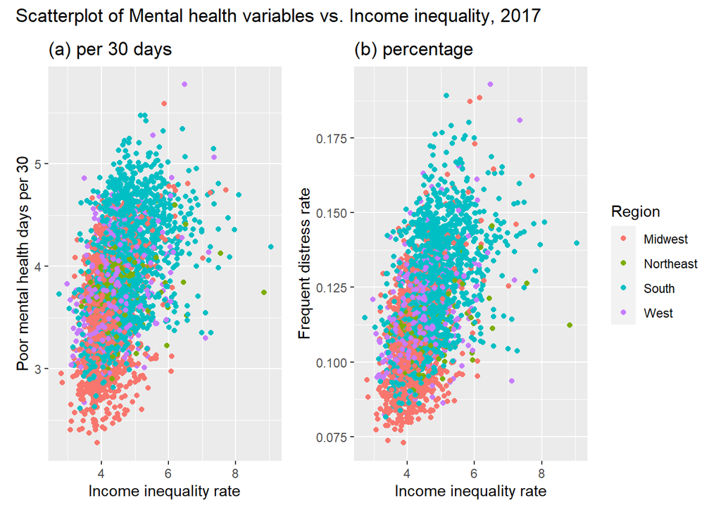

```r
# 2016 mental_health_days data looks weird (like it's been rounded)
# let's check 2017
p1 <- ggplot(ranked17, aes(y=mental_health_days, x=inequality, color = factor(region))) +
  geom_point(show.legend = F) +
  labs(title = "(a) per 30 days",
       y = 'Poor mental health days per 30', x = 'Income inequality rate',
       color = color_value)

p2 <- ggplot(ranked17, aes(y=mental_distress_rate, x=inequality, color = factor(region))) +
  geom_point() +
  labs(title = "(b) percentage",
       y = 'Frequent distress rate', x = 'Income inequality rate',
       color = color_value)

p17 <- p1 + p2 + plot_annotation(title = "Scatterplot of Mental health variables vs. Income inequality, 2017")
p17
```

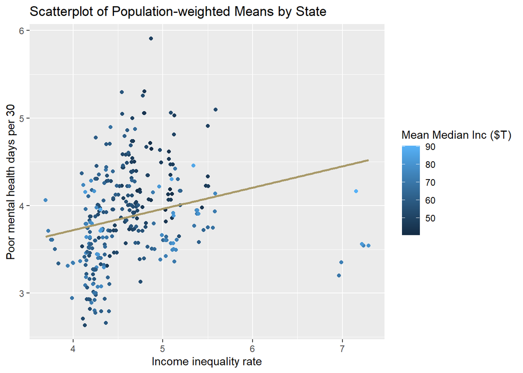

```r
# data: use summ_by_year_state
# aggregated to the state level

#-- Dependent vs Explanatory --#

# means by state
color_value <- "Mean Median Inc ($T)"

ggplot(summ_by_year_state, aes(y=wmean_mh_days, x=wmean_inequality, color=wmean_medinc/1000)) +
  geom_point() +
  geom_smooth(formula = y ~ x, method=lm, se=FALSE, color="#a89968") +
  labs(title = "Scatterplot of Population-weighted Means by State",
       y = 'Poor mental health days per 30', x = 'Income inequality rate',
       color = color_value)
```

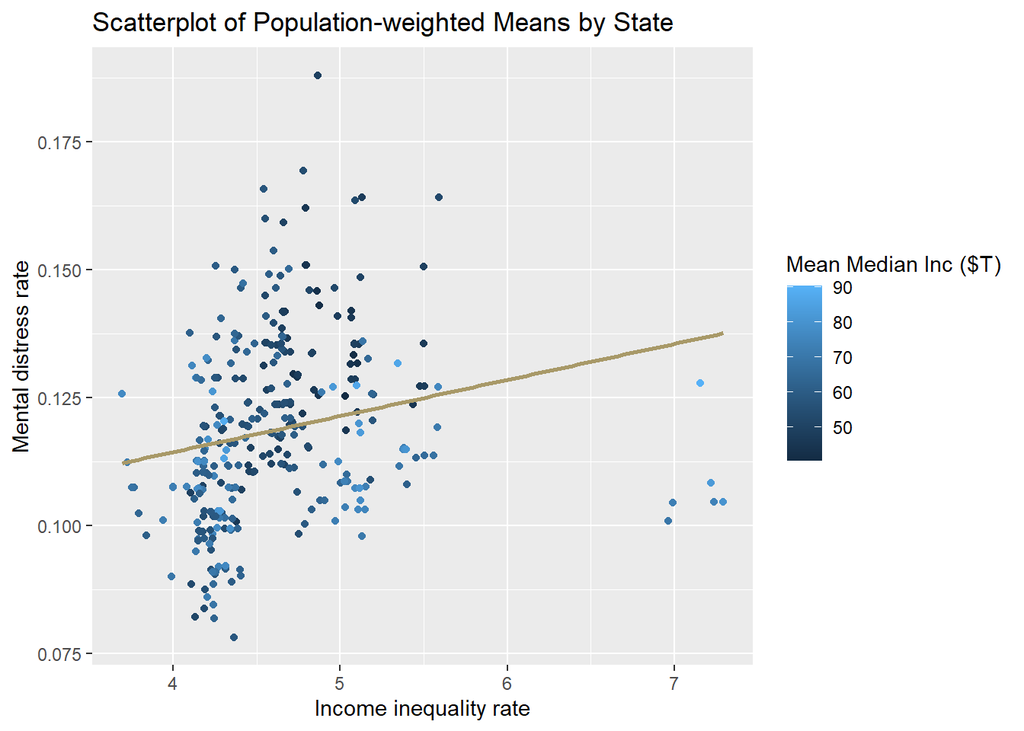

```r
ggplot(summ_by_year_state, aes(y=wmean_mh_rate, x=wmean_inequality, color=wmean_medinc/1000)) +
  geom_point() +
  geom_smooth(formula = y ~ x, method=lm, se=FALSE, color="#a89968") +
  labs(title = "Scatterplot of Population-weighted Means by State",
       y = 'Mental distress rate', x = 'Income inequality rate',
       color = color_value)
```

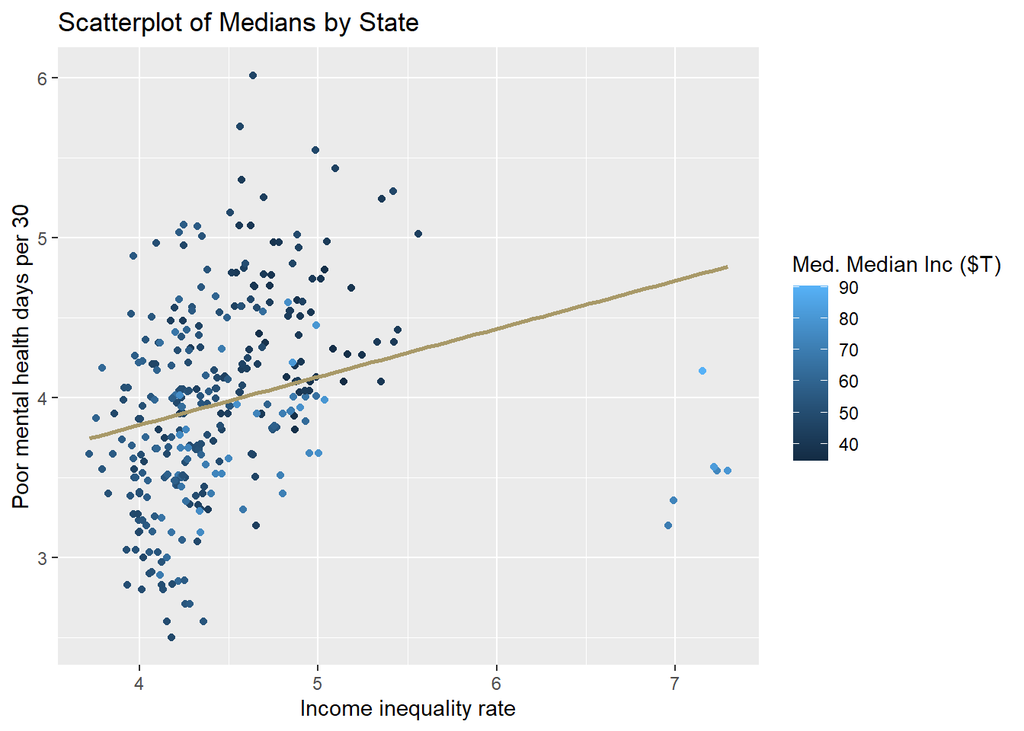

```r
# medians by state
color_value <- "Med. Median Inc ($T)"

ggplot(summ_by_year_state, aes(y=med_mh_days, x=med_inequality, color=med_medinc/1000)) +
  geom_point() +
  geom_smooth(formula = y ~ x, method=lm, se=FALSE, color="#a89968") +  ## Add linear regression line
  labs(title = "Scatterplot of Medians by State",
       y = 'Poor mental health days per 30', x = 'Income inequality rate',
       color = color_value)
```

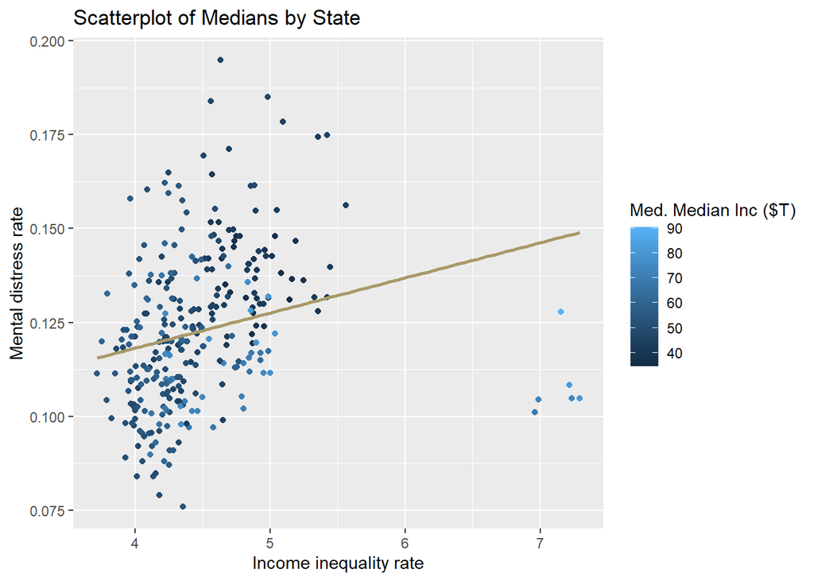

```r
ggplot(summ_by_year_state, aes(y=med_mh_rate, x=med_inequality, color=med_medinc/1000)) +
  geom_point() +
  geom_smooth(formula = y ~ x, method=lm, se=FALSE, color="#a89968") +
  labs(title = "Scatterplot of Medians by State",
       y = 'Mental distress rate', x = 'Income inequality rate',
       color = color_value)
```

```r
# https://www.r-bloggers.com/2016/07/quick-plot-of-all-variables/

keep_var <- c('inequality', 'unempl', 'child_poverty', 'hs_grad', 'college', 'single_parent', 'severe_housing', 'food_index', 'mental_health_days', 'mental_distress_rate', 'median_inc')

#ranked[keep_var]

ranked[keep_var] %>%
  gather() %>%
  ggplot(aes(x=value)) +
    facet_wrap(~ key, scales = "free") +
    geom_histogram(bins=50)
```

[output not shown]

```r
# Shumel -- please work on some histograms
```

```r
# Xuan -- please work on some boxplots
```

## Measures of Variation

*When applicable.*

**Assigned to:** Xuan

Variance, standard deviation, etc.

## Normality tests

*When applicable.*

**Assigned to:** Shumel

For example, histograms, Q-Q plots, etc. Try `ezids::outlierKD2()` function if necessary.

```r
qqnorm()
qqline()
```

## Initial Correlation and Hypothesis Tests

*When applicable.*

**Assigned to:** Alex (with help from Mark)

For example, Chi Square tests, ANOVA analysis, Z-test or Z-interval, T-test or T-interval, etc.

```r
t.test()

table() ## creates contingency table
chisq.test()

aov(y ~ x, data=)


pairs()
cor() ## correlation matrix
corrplot()
```

```r
# Estimation: Establish confidence intervals
# t-interval by region for inequality, mental_health_days, mental_distress_rate

# estimate for all regions
ttest99_in <- t.test(x=ranked$inequality, conf.level=0.99)
ttest99_mh_days <- t.test(x=ranked$mental_health_days, conf.level=0.99)
ttest99_mh_rate <- t.test(x=ranked$mental_distress_rate, conf.level=0.99)

ci99_in <- paste0("[", paste0(round(ttest99_in$conf.int, 4), collapse = ", "), "]")

ci99_mh_days <- paste0("[", paste0(round(ttest99_mh_days$conf.int, 4), collapse = ", "), "]")

ci99_mh_rate <- paste0("[", paste0(round(ttest99_mh_rate$conf.int, 4), collapse = ", "), "]")

var_list <- c("inequality", "mental_health_days", "mental_distress_rate")

ci_list <- list(rep(c("all"), times = length(var_list)), var_list, c(ci99_in, ci99_mh_days, ci99_mh_rate))


# estimate by region
region_list <- c("Midwest", "Northeast", "South", "West")

for (r in region_list) {  ## region names

  ranked_region <- ranked %>% subset(region==r)

  ttest99_in <- t.test(ranked_region$inequality, conf.level=0.99)
  ttest99_mh_days <- t.test(ranked_region$mental_health_days, conf.level=0.99)
  ttest99_mh_rate <- t.test(ranked_region$mental_distress_rate, conf.level=0.99)

  ci99_in <- paste0("[", paste0(round(ttest99_in$conf.int, 4), collapse = ", "), "]")

  ci99_mh_days <- paste0("[", paste0(round(ttest99_mh_days$conf.int, 4), collapse = ", "), "]")

  ci99_mh_rate <- paste0("[", paste0(round(ttest99_mh_rate$conf.int, 4), collapse = ", "), "]")

  ci_list[[1]] <- append(ci_list[[1]], rep(c(r), times = length(var_list)))
  ci_list[[2]] <- append(ci_list[[2]], var_list)
  ci_list[[3]] <- append(ci_list[[3]], c(ci99_in, ci99_mh_days, ci99_mh_rate))

  #print(ci_list)
}

# print results
for (n in 1:15) {

  print(paste(ci_list[[1]][n], ci_list[[2]][n], ci_list[[3]][n], sep=" | "))

}
```

```
## [1] "all | inequality | [4.5097, 4.5375]"
## [1] "all | mental_health_days | [4.0266, 4.0529]"
## [1] "all | mental_distress_rate | [0.1256, 0.1265]"
## [1] "Midwest | inequality | [4.1641, 4.2011]"
## [1] "Midwest | mental_health_days | [3.686, 3.7301]"
## [1] "Midwest | mental_distress_rate | [0.115, 0.1165]"
## [1] "Northeast | inequality | [4.4926, 4.5863]"
## [1] "Northeast | mental_health_days | [3.9758, 4.041]"
## [1] "Northeast | mental_distress_rate | [0.1193, 0.1215]"
## [1] "South | inequality | [4.7855, 4.8277]"
## [1] "South | mental_health_days | [4.315, 4.3513]"
## [1] "South | mental_distress_rate | [0.1355, 0.1368]"
## [1] "West | inequality | [4.3659, 4.4358]"
## [1] "West | mental_health_days | [3.8556, 3.9113]"
## [1] "West | mental_distress_rate | [0.1196, 0.1216]"
```

Estimate the t-intervals of our key variables at the 99% confidence level.

The t-intervals by region are reported for each variable of interest in the following table:

[output not shown]

```r
# Hypothesis Testing: Test the process of making decisions about the value of a population parameter

# difference in means
# - rural vs urban (create binary indicator at 50%?)
# - across report years (2017 to 2021)
# - by region (ANOVA or chi-sq??)
```

## Linear Modeling and Regression

*When applicable. Might not need at all.*

**Assigned to:** TBD

```r
lm()
xkablevif()
anova()
xkabledply()
```